# Weak Free Choice (Study 3)

Bartosz

# Introduction

This report presents an analysis of the “Weak Free Choice” experiment, based on the version with soft instructions and reminders. The analysis is structured into two main parts:

# Data Preparation

We begin by loading the raw data and performing several cleaning and preparation steps. This includes standardizing response codes, creating a `trial_type` factor based on item combinations, and creating clean, descriptive labels for plotting.

```r
# ----- 1) Load and Combine Data -----
data_raw <- read.csv("results.csv")

# ----- 2) Initial Cleaning and Tidying -----
data_all <- data_raw %>%
  mutate(
    # Standardize response coding (1 for "b", 0 for "n")
    resp = case_when(
      response %in% c("b", "B") ~ 1,
      response %in% c("n", "N") ~ 0,
      TRUE ~ NA_real_
    ),
    # Keep original condition labels (useful for paper tables)
    condition_full = condition,
    # Some disjunction items include ITEM2 but have an empty ITEM2_TYPE in the results export
    # (typically double-control disjunctions). In those cases, infer ITEM2_TYPE from ITEM1_TYPE.
    ITEM2_TYPE = case_when(
      ITEM2_TYPE == "" & ITEM2 != "" ~ ITEM1_TYPE,
      TRUE ~ ITEM2_TYPE
    ),
    # Create a descriptive trial type factor
    trial_type = factor(case_when(
      (ITEM1_TYPE == "accepts" & ITEM2_TYPE == "wants") | (ITEM1_TYPE == "wants" & ITEM2_TYPE == "accepts") ~ "Wants + Accepts",
      (ITEM1_TYPE == "accepts" & ITEM2_TYPE == "dislikes") | (ITEM1_TYPE == "dislikes" & ITEM2_TYPE == "accepts") ~ "Dislikes + Accepts",
      (ITEM1_TYPE == "wants" & ITEM2_TYPE == "dislikes") | (ITEM1_TYPE == "dislikes" & ITEM2_TYPE == "wants") ~ "Wants + Dislikes",
      (ITEM1_TYPE == "wants" & ITEM2_TYPE == "wants") ~ "Wants + Wants",
      (ITEM1_TYPE == "dislikes" & ITEM2_TYPE == "dislikes") ~ "Dislikes + Dislikes",
      (ITEM1_TYPE == "accepts" & ITEM2_TYPE == "accepts") ~ "Accepts + Accepts",
      (ITEM1_TYPE == "wants" & ITEM2_TYPE == "") ~ "Wants",
      (ITEM1_TYPE == "dislikes" & ITEM2_TYPE == "") ~ "Dislikes",
      (ITEM1_TYPE == "accepts" & ITEM2_TYPE == "") ~ "Accepts"
    )),
    # Collapse 'MIND' conditions into their base versions
    condition_raw = case_when(
      condition_full %in% c("DOUBLE_CONTROL", "DOUBLE_CONTROL_MIND") ~ "DOUBLE_CONTROL",
      condition_full %in% c("SINGLE_CONTROL", "SINGLE_CONTROL_MIND") ~ "SINGLE_CONTROL",
      condition_full %in% c("EXPERIMENTAL", "EXPERIMENTAL_MIND") ~ "EXPERIMENTAL"
    ),
    # Create a separate column with pretty labels for plotting
    condition_label = factor(
      case_when(
        condition_raw == "DOUBLE_CONTROL" ~ "Double Control",
        condition_raw == "SINGLE_CONTROL" ~ "Single Control",
        condition_raw == "EXPERIMENTAL" ~ "Experimental"
      ),
      levels = c("Double Control", "Single Control", "Experimental")
    ),
    # Create an adjusted response variable for correctness (1 = Correct, 0 = Incorrect)
    resp_adj = case_when(
      correct == "Y" & resp == 1 ~ 1,
      correct == "N" & resp == 0 ~ 1,
      correct == "Y/N" & resp == 1 ~ 1, # Treating Y/N as correct for 'TRUE'
      TRUE ~ 0
    ),
    # Factorize key variables for modeling
    condition = factor(condition_raw, levels = c("DOUBLE_CONTROL", "SINGLE_CONTROL", "EXPERIMENTAL")),
    single_or_double = if_else(condition == "SINGLE_CONTROL", "SINGLE", "DOUBLE")
  )

data_practice <- data_all %>% filter(SESSION == "PRACTICE")
data_main <- data_all %>% filter(SESSION == "EXPERIMENTAL")

cat(paste0(
  "Loaded ",
  n_distinct(data_main$PARTICIPANT),
  " participant(s) with ",
  nrow(data_practice),
  " practice trials and ",
  nrow(data_main),
  " main-session trials."
))
```

```
## Loaded 58 participant(s) with 2320 practice trials and 7076 main-session trials.
```

# Demographics (Prolific export)

```r
prolific_files <- list.files(".", pattern = "^prolific_export_.*\\.csv$", full.names = TRUE)
if (length(prolific_files) == 0) stop("No Prolific export CSV found in the results folder.")
prolific_path <- prolific_files[which.max(file.info(prolific_files)$mtime)]

prolific <- read_csv(prolific_path, show_col_types = FALSE) %>%
  rename(
    PROLIFIC_PID = `Participant id`,
    Status = Status,
    Time_taken_sec = `Time taken`,
    Age_years = Age,
    Sex = Sex
  ) %>%
  mutate(
    Age_years = suppressWarnings(as.numeric(Age_years)),
    Time_taken_sec = suppressWarnings(as.numeric(Time_taken_sec))
  )

matched_ids <- unique(as.character(data_main$PARTICIPANT))
demog <- prolific %>% filter(PROLIFIC_PID %in% matched_ids)
missing_demog <- setdiff(matched_ids, demog$PROLIFIC_PID)

approved_all <- prolific %>% filter(Status == "APPROVED")
unmatched_rows <- prolific %>% filter(!(PROLIFIC_PID %in% matched_ids))
unmatched_by_status <- unmatched_rows %>%
  count(Status, name = "N") %>%
  arrange(desc(N))

sec_to_mmss <- function(sec) {
  s <- as.integer(round(sec))
  sprintf("%02d:%02d", s %/% 60, s %% 60)
}

median_matched_sec <- median(demog$Time_taken_sec, na.rm = TRUE)
median_approved_sec <- median(approved_all$Time_taken_sec, na.rm = TRUE)

demog_summary <- tibble(
  `Matched participants` = n_distinct(demog$PROLIFIC_PID),
  `Participants in data` = length(matched_ids),
  `Mean age` = round(mean(demog$Age_years, na.rm = TRUE), 1),
  `SD age` = round(sd(demog$Age_years, na.rm = TRUE), 1),
  `Age range` = paste0(min(demog$Age_years, na.rm = TRUE), "-", max(demog$Age_years, na.rm = TRUE)),
  `Median completion (matched, mm:ss)` = sec_to_mmss(median_matched_sec),
  `Median completion (approved, mm:ss)` = sec_to_mmss(median_approved_sec)
)

sex_table <- demog %>%
  count(Sex, name = "Count") %>%
  mutate(Percent = percent(Count / sum(Count), accuracy = 0.1))

paper_demog_text <- paste0(
  "Matched participants = ", n_distinct(demog$PROLIFIC_PID),
  "; age M = ", round(mean(demog$Age_years, na.rm = TRUE), 1),
  " (SD = ", round(sd(demog$Age_years, na.rm = TRUE), 1),
  ", range ", min(demog$Age_years, na.rm = TRUE), "-", max(demog$Age_years, na.rm = TRUE), "); ",
  "median completion matched = ", sec_to_mmss(median_matched_sec),
  "; median completion approved = ", sec_to_mmss(median_approved_sec), "."
)
```

Matched participants = 58; age M = 39.1 (SD = 12.9, range 18-71); median completion matched = 19:16; median completion approved = 19:35.

Matched demographics summary:

```r
demog_summary %>% flextable() %>% autofit()
```

| Matched participants | Participants in data | Mean age | SD age | Age range | Median completion (matched, mm:ss) | Median completion (approved, mm:ss) |
| --- | --- | --- | --- | --- | --- | --- |
| 58 | 58 | 39.1 | 12.9 | 18-71 | 19:16 | 19:35 |

Sex distribution (matched participants):

```r
sex_table %>% flextable() %>% autofit()
```

| Sex | Count | Percent |
| --- | --- | --- |
| Female | 25 | 43.1% |
| Male | 32 | 55.2% |
| Prefer not to say | 1 | 1.7% |

Prolific rows not matched to Study 3 trial data (by status):

```r
if (nrow(unmatched_by_status) > 0) {
  unmatched_by_status %>% flextable() %>% autofit()
} else {
  cat("No unmatched Prolific rows.")
}
```

| Status | N |
| --- | --- |
| RETURNED | 9 |
| APPROVED | 2 |

Missing demographics for participant IDs in trial data (if any):

```r
if (length(missing_demog) > 0) {
  tibble(`Unmatched participant ID` = missing_demog) %>% flextable() %>% autofit()
} else {
  cat("All participants with trial data matched to Prolific demographics.")
}
```

All participants with trial data matched to Prolific demographics.

# Stimuli inventory (paper methods)

Unique stimuli counts: practice = 40 item(s), main session = 122 item(s).

Main-session items by condition and verb (unique stimuli):

```r
main_counts_by_condition %>% flextable() %>% autofit()
```

| condition_full | verb | N items |
| --- | --- | --- |
| DOUBLE_CONTROL | want | 30 |
| DOUBLE_CONTROL_MIND | does not mind | 8 |
| EXPERIMENTAL | does not mind | 4 |
| EXPERIMENTAL | want | 30 |
| SINGLE_CONTROL | want | 42 |
| SINGLE_CONTROL_MIND | does not mind | 8 |

Main-session items by condition, verb, and item type (unique stimuli):

```r
main_counts_by_condition_and_type %>% flextable() %>% autofit()
```

| condition_full | verb | trial_type | correct | N items |
| --- | --- | --- | --- | --- |
| DOUBLE_CONTROL | want | Accepts + Accepts | N | 10 |
| DOUBLE_CONTROL | want | Dislikes + Dislikes | N | 10 |
| DOUBLE_CONTROL | want | Wants + Wants | Y | 10 |
| DOUBLE_CONTROL_MIND | does not mind | Accepts + Accepts | Y | 4 |
| DOUBLE_CONTROL_MIND | does not mind | Dislikes + Dislikes | N | 4 |
| EXPERIMENTAL | does not mind | Dislikes + Accepts | Y/N | 4 |
| EXPERIMENTAL | want | Dislikes + Accepts | Y/N | 10 |
| EXPERIMENTAL | want | Wants + Accepts | Y/N | 10 |
| EXPERIMENTAL | want | Wants + Dislikes | Y/N | 10 |
| SINGLE_CONTROL | want | Accepts | N | 14 |
| SINGLE_CONTROL | want | Dislikes | N | 14 |
| SINGLE_CONTROL | want | Wants | Y | 14 |
| SINGLE_CONTROL_MIND | does not mind | Accepts | Y | 4 |
| SINGLE_CONTROL_MIND | does not mind | Dislikes | N | 4 |

Want-disjunction items in the experimental set (unique stimuli):

```r
want_disjunction_inventory %>%
  rename(
    `Disjunction type` = disjunction_type,
    `Order` = better_first
  ) %>%
  flextable() %>%
  autofit()
```

| Disjunction type | Order | N items |
| --- | --- | --- |
| accepts ∨ dislikes | better-first | 5 |
| accepts ∨ dislikes | better-second | 5 |
| wants ∨ accepts | better-first | 5 |
| wants ∨ accepts | better-second | 5 |
| wants ∨ dislikes | better-first | 5 |
| wants ∨ dislikes | better-second | 5 |

Does-not-mind disjunction items in the experimental set (unique stimuli):

```r
mind_disjunction_inventory %>%
  rename(
    `Disjunction type` = disjunction_type,
    `Order` = accepts_first
  ) %>%
  flextable() %>%
  autofit()
```

| Disjunction type | Order | N items |
| --- | --- | --- |
| accepts ∨ dislikes | accepts-first | 2 |
| accepts ∨ dislikes | accepts-second | 2 |

# Paper-ready summaries

## Descriptive TRUE-response rates by item type (main session)

```r
paper_descriptives %>% flextable() %>% autofit()
```

| Condition | Mean TRUE | SD | 95% CI | N participants |
| --- | --- | --- | --- | --- |
| Single control: wants (true) | 84.5% | 16.9% | [80.0%, 88.9%] | 58 |
| Single control: accepts (false) | 36.1% | 40.0% | [25.6%, 46.6%] | 58 |
| Single control: dislikes (false) | 19.2% | 18.5% | [14.4%, 24.1%] | 58 |
| Double control: wants ∨ wants (true) | 83.6% | 17.3% | [79.1%, 88.2%] | 58 |
| Double control: accepts ∨ accepts (false) | 37.1% | 42.0% | [26.0%, 48.1%] | 58 |
| Double control: dislikes ∨ dislikes (false) | 16.4% | 18.8% | [11.4%, 21.3%] | 58 |
| Experimental: wants ∨ accepts (wants-first) | 56.6% | 38.8% | [46.4%, 66.7%] | 58 |
| Experimental: wants ∨ accepts (wants-second) | 54.5% | 38.2% | [44.4%, 64.5%] | 58 |
| Experimental: wants ∨ dislikes (wants-first) | 38.3% | 33.8% | [29.4%, 47.2%] | 58 |
| Experimental: wants ∨ dislikes (wants-second) | 32.8% | 31.3% | [24.5%, 41.0%] | 58 |
| Experimental: accepts ∨ dislikes (accepts-first) | 20.0% | 29.3% | [12.3%, 27.7%] | 58 |
| Experimental: accepts ∨ dislikes (accepts-second) | 25.9% | 32.2% | [17.4%, 34.3%] | 58 |
| Single control (does not mind): accepts (true) | 88.4% | 19.4% | [83.3%, 93.5%] | 58 |
| Single control (does not mind): dislikes (false) | 24.1% | 26.9% | [17.1%, 31.2%] | 58 |
| Double control (does not mind): accepts ∨ accepts (true) | 85.3% | 21.0% | [79.8%, 90.9%] | 58 |
| Double control (does not mind): dislikes ∨ dislikes (false) | 24.6% | 30.5% | [16.5%, 32.6%] | 58 |
| Experimental (does not mind): accepts ∨ dislikes (accepts-first) | 37.9% | 37.8% | [28.0%, 47.9%] | 58 |
| Experimental (does not mind): accepts ∨ dislikes (accepts-second) | 41.4% | 38.8% | [31.2%, 51.6%] | 58 |

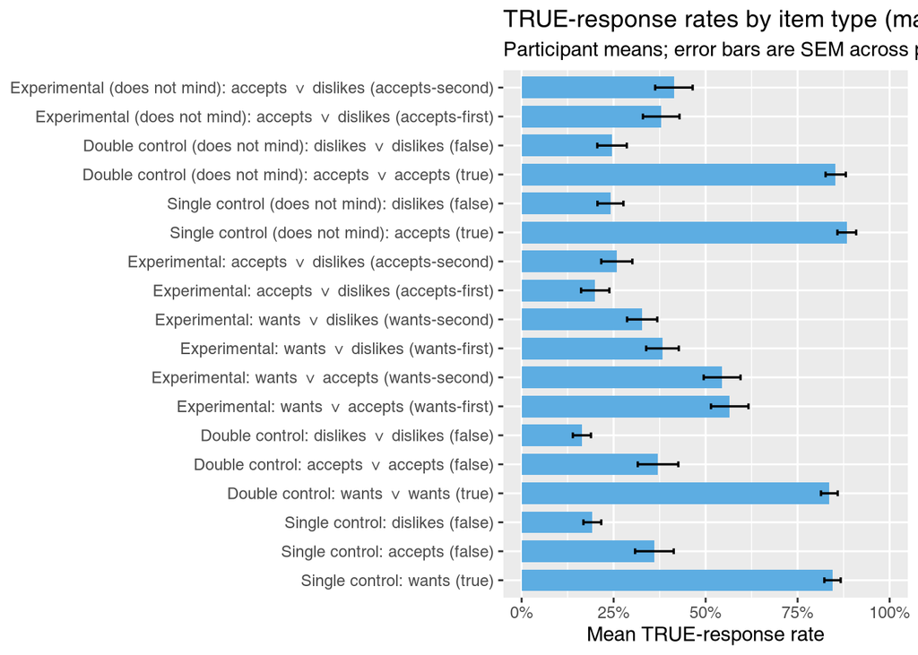

```r
paper_plot_data <- paper_conditions %>%
  group_by(paper_condition) %>%
  summarise(
    mean = mean(mean_true, na.rm = TRUE),
    se = sd(mean_true) / sqrt(n()),
    .groups = "drop"
  )

ggplot(paper_plot_data, aes(paper_condition, mean)) +
  geom_col(fill = "#5DADE2", width = 0.75) +
  geom_errorbar(aes(ymin = mean - se, ymax = mean + se), width = 0.2, linewidth = 0.6) +
  coord_flip() +
  scale_y_continuous(labels = percent_format(accuracy = 1), limits = c(0, 1)) +
  labs(
    title = "TRUE-response rates by item type (main session)",
    subtitle = "Participant means; error bars are SEM across participants",
    x = NULL,
    y = "Mean TRUE-response rate"
  )
```

## Want disjunctions (order-collapsed): single overarching model

```r
want_disj <- data_main %>%
  filter(
    verb == "want",
    trial_type %in% c(
      "Wants + Wants",
      "Accepts + Accepts",
      "Dislikes + Dislikes",
      "Wants + Accepts",
      "Wants + Dislikes",
      "Dislikes + Accepts"
    )
  ) %>%
  mutate(
    disj_type = case_when(
      trial_type == "Wants + Wants" ~ "W+W",
      trial_type == "Wants + Accepts" ~ "W+A",
      trial_type == "Wants + Dislikes" ~ "W+D",
      trial_type == "Dislikes + Accepts" ~ "A+D",
      trial_type == "Accepts + Accepts" ~ "A+A",
      trial_type == "Dislikes + Dislikes" ~ "D+D",
      TRUE ~ NA_character_
    ),
    disj_type = factor(disj_type, levels = c("W+W", "W+A", "W+D", "A+D", "A+A", "D+D")),
    participant = factor(PARTICIPANT),
    item_id = factor(item)
  ) %>%
  filter(!is.na(resp), !is.na(disj_type))

cat(paste0(
  "Want-disjunction trials: ",
  nrow(want_disj),
  "; participants: ",
  n_distinct(want_disj$participant),
  "; items: ",
  n_distinct(want_disj$item_id),
  "."
))
```

```
## Want-disjunction trials: 3480; participants: 58; items: 60.
```

```r
critical_model <- glmer(
  resp ~ disj_type + (1 | participant) + (1 | item_id),
  data = want_disj,
  family = binomial,
  control = glmerControl(optimizer = "bobyqa", optCtrl = list(maxfun = 2e5))
)
tab_model(critical_model)
```

|  | resp |  |  |
| --- | --- | --- | --- |
| Predictors | Odds Ratios | CI | p |
| (Intercept) | 7.10 | 4.96 – 10.18 | **<0.001** |
| disj type [W+A] | 0.18 | 0.13 – 0.25 | **<0.001** |
| disj type [W+D] | 0.07 | 0.05 – 0.09 | **<0.001** |
| disj type [A+D] | 0.03 | 0.02 – 0.05 | **<0.001** |
| disj type [A+A] | 0.07 | 0.05 – 0.10 | **<0.001** |
| disj type [D+D] | 0.02 | 0.01 – 0.03 | **<0.001** |
| Random Effects |  |  |  |
| σ<sup>2</sup> | 3.29 |  |  |
| τ<sub>00</sub> <sub>item_id</sub> | 0.00 |  |  |
| τ<sub>00</sub> <sub>participant</sub> | 1.04 |  |  |
| ICC | 0.24 |  |  |
| N <sub>participant</sub> | 58 |  |  |
| N <sub>item_id</sub> | 60 |  |  |
| Observations | 3480 |  |  |
| Marginal R<sup>2</sup> / Conditional R<sup>2</sup> | 0.272 / 0.448 |  |  |

```r
emm <- emmeans(critical_model, ~ disj_type, weights = "proportional", type = "response")
as.data.frame(summary(emm, infer = c(TRUE, TRUE))) %>%
  mutate(across(c(prob, asymp.LCL, asymp.UCL), ~ scales::percent(.x, accuracy = 0.1))) %>%
  select(disj_type, prob, asymp.LCL, asymp.UCL, z.ratio, p.value) %>%
  flextable() %>%
  autofit()
```

| disj_type | prob | asymp.LCL | asymp.UCL | z.ratio | p.value |
| --- | --- | --- | --- | --- | --- |
| W+W | 87.7% | 83.2% | 91.1% | 10.682898 | 0.000000000000000000000000012239004 |
| W+A | 56.5% | 48.5% | 64.1% | 1.586495 | 0.112627078687779672017121868066170 |
| W+D | 32.2% | 25.5% | 39.6% | -4.503664 | 0.000006679185332970143345980573724 |
| A+D | 18.7% | 14.0% | 24.4% | -8.512417 | 0.000000000000000017034494464444637 |
| A+A | 34.0% | 27.1% | 41.6% | -4.025445 | 0.000056867617828256223071626412890 |
| D+D | 12.5% | 9.1% | 16.9% | -10.719548 | 0.000000000000000000000000008240549 |

### W+A vs W+D (order-collapsed; model-based)

```r
emm_disj <- emmeans(critical_model, ~ disj_type, weights = "proportional")

overall_contrast <- summary(
  contrast(
    emm_disj,
    method = list(
      "W+A - W+D" = c(0, 1, -1, 0, 0, 0)
    )
  ),
  infer = c(TRUE, TRUE)
)

as.data.frame(overall_contrast) %>%
  mutate(
    lcl = if ("lower.CL" %in% names(.)) lower.CL else asymp.LCL,
    ucl = if ("upper.CL" %in% names(.)) upper.CL else asymp.UCL,
    OR = exp(estimate),
    OR_low = exp(lcl),
    OR_high = exp(ucl),
    `OR (95% CI)` = paste0(
      round(OR, 2),
      " [",
      round(OR_low, 2),
      ", ",
      round(OR_high, 2),
      "]"
    ),
    z = round(z.ratio, 2),
    p = format.pval(p.value, digits = 3, eps = .001)
  ) %>%
  select(contrast, `OR (95% CI)`, z, p) %>%
  flextable() %>%
  autofit()
```

| contrast | OR (95% CI) | z | p |
| --- | --- | --- | --- |
| W+A - W+D | 2.73 [2.1, 3.56] | 7.46 | <0.001 |

### Midpoint (50%) tests (model-based; emmeans)

```r
# Midpoint tests on model-estimated marginal probabilities (averaged over disjunct order).
# Note: tests are performed on the logit scale (so 0 corresponds to 50% on the response scale).
emm_midpoint <- emmeans(critical_model, ~ disj_type, weights = "proportional")

midpoint_model_tbl <- as.data.frame(summary(emm_midpoint, type = "response", infer = c(TRUE, TRUE))) %>%
  mutate(
    Direction = if_else(prob > 0.5, "above 50%", "below 50%"),
    `Predicted TRUE` = percent(prob, accuracy = 0.1),
    `95% CI` = paste0(
      "[",
      percent(asymp.LCL, accuracy = 0.1),
      ", ",
      percent(asymp.UCL, accuracy = 0.1),
      "]"
    ),
    z = round(z.ratio, 2),
    p = format.pval(p.value, digits = 3, eps = .001)
  ) %>%
  filter(disj_type %in% c("W+A", "W+D")) %>%
  mutate(`Disjunction type` = recode(disj_type, `W+A` = "wants ∨ accepts (W+A)", `W+D` = "wants ∨ dislikes (W+D)")) %>%
  select(`Disjunction type`, Direction, `Predicted TRUE`, `95% CI`, z, p)

midpoint_model_tbl %>% flextable() %>% autofit()
```

| Disjunction type | Direction | Predicted TRUE | 95% CI | z | p |
| --- | --- | --- | --- | --- | --- |
| wants ∨ accepts (W+A) | above 50% | 56.5% | [48.5%, 64.1%] | 1.59 | 0.113 |
| wants ∨ dislikes (W+D) | below 50% | 32.2% | [25.5%, 39.6%] | -4.50 | <0.001 |

## Benchmark: W+W (double control) vs W+A (experimental)

This contrast targets the strong-FC-style prediction that `want (A or B)` is evaluated as a *conjunctive* requirement that **both** disjuncts are wanted. Under that reading, `wants ∨ accepts` (W+A) should be rejected relative to the `wants ∨ wants` (W+W) double-control disjunctions.

```r
emm_disj <- emmeans(critical_model, ~ disj_type, weights = "proportional")

ww_vs_wa_contrast <- summary(
  contrast(
    emm_disj,
    method = list(
      "W+A - W+W" = c(-1, 1, 0, 0, 0, 0)
    )
  ),
  infer = c(TRUE, TRUE)
)

as.data.frame(ww_vs_wa_contrast) %>%
  mutate(
    lcl = if ("lower.CL" %in% names(.)) lower.CL else asymp.LCL,
    ucl = if ("upper.CL" %in% names(.)) upper.CL else asymp.UCL,
    OR = exp(estimate),
    OR_low = exp(lcl),
    OR_high = exp(ucl),
    `OR (95% CI)` = paste0(
      round(OR, 2),
      " [",
      round(OR_low, 2),
      ", ",
      round(OR_high, 2),
      "]"
    ),
    z = round(z.ratio, 2),
    p = format.pval(p.value, digits = 3, eps = .001)
  ) %>%
  select(contrast, `OR (95% CI)`, z, p) %>%
  flextable() %>%
  autofit()
```

| contrast | OR (95% CI) | z | p |
| --- | --- | --- | --- |
| W+A - W+W | 0.18 [0.13, 0.25] | -10.89 | <0.001 |

## Exploratory: item-level heterogeneity in W+W (double control)

This diagnostic is useful if some true W+W control disjunctions are unexpectedly rejected. The table below lists W+W items ranked by their mean TRUE response rate (collapsed across participants).

```r
ww_items <- data_main %>%
  filter(
    condition_full == "DOUBLE_CONTROL",
    verb == "want",
    trial_type == "Wants + Wants"
  ) %>%
  group_by(item, sentence, ITEM1, ITEM2) %>%
  summarise(
    mean_true = mean(resp, na.rm = TRUE),
    .groups = "drop"
  ) %>%
  mutate(
    wanted_domain = case_when(
      ITEM1 %in% sweets_study3 ~ "sweets",
      ITEM1 %in% fruits_study3 ~ "fruits",
      TRUE ~ "other"
    )
  ) %>%
  arrange(mean_true)

ww_items %>%
  mutate(`Mean TRUE` = scales::percent(mean_true, accuracy = 0.1)) %>%
  select(
    Item = item,
    `Wanted domain` = wanted_domain,
    `Disjunct 1` = ITEM1,
    `Disjunct 2` = ITEM2,
    `Mean TRUE`
  ) %>%
  flextable() %>%
  autofit()
```

| Item | Wanted domain | Disjunct 1 | Disjunct 2 | Mean TRUE |
| --- | --- | --- | --- | --- |
| D21 | fruits | a mango | an orange | 72.4% |
| D18 | fruits | an orange | a cherry | 75.9% |
| D24 | fruits | a plum | a mango | 79.3% |
| D27 | fruits | a peach | a plum | 81.0% |
| D15 | fruits | a cherry | a pear | 84.5% |
| D3 | sweets | a cookie | a chocolate | 86.2% |
| D6 | sweets | a biscuit | a cookie | 86.2% |
| D0 | sweets | a chocolate | a brownie | 89.7% |
| D9 | sweets | a lollipop | a biscuit | 89.7% |
| D12 | sweets | a cupcake | a lollipop | 91.4% |

### Exploratory: are W+W disjunction controls depressed relative to W single controls?

If participants systematically interpret `or` as exclusive (or if disjunct pairs are pragmatically hard to satisfy jointly), then even true W+W disjunctions might be rejected more than true W single controls. We test this on participant-mean TRUE rates.

```r
want_controls_w <- data_main %>%
  filter(
    verb == "want",
    (condition_full == "SINGLE_CONTROL" & trial_type == "Wants") |
      (condition_full == "DOUBLE_CONTROL" & trial_type == "Wants + Wants")
  ) %>%
  mutate(
    control_type = case_when(
      condition_full == "SINGLE_CONTROL" ~ "W (single control)",
      condition_full == "DOUBLE_CONTROL" ~ "W+W (double control)",
      TRUE ~ NA_character_
    ),
    control_type = factor(control_type, levels = c("W (single control)", "W+W (double control)"))
  ) %>%
  filter(!is.na(control_type))

subj_controls_w <- want_controls_w %>%
  group_by(PARTICIPANT, control_type) %>%
  summarise(mean_true = mean(resp, na.rm = TRUE), .groups = "drop") %>%
  tidyr::pivot_wider(names_from = control_type, values_from = mean_true)

tt_controls_w <- t.test(
  subj_controls_w$`W+W (double control)`,
  subj_controls_w$`W (single control)`,
  paired = TRUE
)

controls_w_tbl <- tibble(
  Contrast = "W+W (double) vs W (single)",
  `Mean difference (W+W - W)` = scales::percent(mean(subj_controls_w$`W+W (double control)` - subj_controls_w$`W (single control)`), accuracy = 0.1),
  t = round(unname(tt_controls_w$statistic), 2),
  df = unname(tt_controls_w$parameter),
  p = format.pval(tt_controls_w$p.value, digits = 3, eps = .001)
)

controls_w_tbl %>% flextable() %>% autofit()
```

| Contrast | Mean difference (W+W - W) | t | df | p |
| --- | --- | --- | --- | --- |
| W+W (double) vs W (single) | -0.9% | -0.48 | 57 | 0.636 |

## Between-study comparison (Study 2 vs Study 3): W+A acceptance

Study 3 was designed to reduce “wants” endorsements for A-category options (accepted-but-not-wanted) via explicit training. A key diagnostic is therefore whether the critical W+A disjunctions (`wants ∨ accepts`) are endorsed *less often* in Study 3 than in Study 2.

```r
# --- Study 2: load and extract W+A want-disjunction trials ---
study2_path <- file.path("..", "..", "Study2", "results", "results.csv")
stopifnot(file.exists(study2_path))

study2_raw <- read.csv(study2_path)

study2_wa <- study2_raw %>%
  filter(
    SESSION == "EXPERIMENTAL",
    condition == "EXPERIMENTAL",
    verb == "want",
    subcondition == "wants|accepts"
  ) %>%
  mutate(
    resp = case_when(
      response %in% c("b", "B") ~ 1,
      response %in% c("n", "N") ~ 0,
      TRUE ~ NA_real_
    ),
    wants_first = item1_type == "wants",
    study = "Study 2",
    participant = factor(paste0("S2_", PARTICIPANT)),
    item_id = factor(paste0("S2_", item))
  ) %>%
  select(study, resp, wants_first, participant, item_id) %>%
  filter(!is.na(resp))

# --- Study 3: extract W+A want-disjunction trials from the already-prepared main-session data ---
study3_wa <- data_main %>%
  filter(
    SESSION == "EXPERIMENTAL",
    condition_full == "EXPERIMENTAL",
    verb == "want",
    trial_type == "Wants + Accepts"
  ) %>%
  mutate(
    wants_first = ITEM1_TYPE == "wants",
    study = "Study 3",
    participant = factor(paste0("S3_", PARTICIPANT)),
    item_id = factor(paste0("S3_", item))
  ) %>%
  select(study, resp, wants_first, participant, item_id) %>%
  filter(!is.na(resp))

# --- Combine and model (between-subject; participants and items are distinct across studies) ---
wa_between <- bind_rows(study2_wa, study3_wa) %>%
  mutate(
    study = factor(study, levels = c("Study 2", "Study 3"))
  )

# Participant-mean descriptives for W+A (collapsed over disjunct order)
wa_subj_means <- wa_between %>%
  group_by(study, participant) %>%
  summarise(mean_true = mean(resp, na.rm = TRUE), .groups = "drop")

wa_desc <- wa_subj_means %>%
  group_by(study) %>%
  summarise(
    n_participants = n_distinct(participant),
    mean = mean(mean_true, na.rm = TRUE),
    sd = sd(mean_true, na.rm = TRUE),
    se = sd / sqrt(n_participants),
    .groups = "drop"
  ) %>%
  mutate(
    ci_mult = qt(0.975, df = n_participants - 1),
    ci_low = mean - ci_mult * se,
    ci_high = mean + ci_mult * se,
    `Mean TRUE` = scales::percent(mean, accuracy = 0.1),
    SD = scales::percent(sd, accuracy = 0.1),
    `95% CI` = paste0(
      "[",
      scales::percent(ci_low, accuracy = 0.1),
      ", ",
      scales::percent(ci_high, accuracy = 0.1),
      "]"
    )
  ) %>%
  select(
    Study = study,
    `Mean TRUE`,
    SD,
    `95% CI`,
    `N participants` = n_participants
  )

wa_desc %>% flextable() %>% autofit()
```

| Study | Mean TRUE | SD | 95% CI | N participants |
| --- | --- | --- | --- | --- |
| Study 2 | 67.2% | 34.4% | [58.2%, 76.3%] | 58 |
| Study 3 | 55.5% | 36.9% | [45.8%, 65.2%] | 58 |

```r
wa_between_model <- glmer(
  resp ~ study * wants_first + (1 | participant) + (1 | item_id),
  data = wa_between,
  family = binomial,
  control = glmerControl(optimizer = "bobyqa", optCtrl = list(maxfun = 2e5))
)

tab_model(wa_between_model)
```

|  | resp |  |  |
| --- | --- | --- | --- |
| Predictors | Odds Ratios | CI | p |
| (Intercept) | 2.82 | 1.35 – 5.89 | **0.006** |
| study [Study 3] | 0.40 | 0.14 – 1.15 | 0.091 |
| wants firstTRUE | 1.50 | 0.90 – 2.49 | 0.119 |
| study [Study 3] × wants firstTRUE | 0.78 | 0.38 – 1.64 | 0.520 |
| Random Effects |  |  |  |
| σ<sup>2</sup> | 3.29 |  |  |
| τ<sub>00</sub> <sub>participant</sub> | 5.94 |  |  |
| τ<sub>00</sub> <sub>item_id</sub> | 0.06 |  |  |
| ICC | 0.65 |  |  |
| N <sub>participant</sub> | 116 |  |  |
| N <sub>item_id</sub> | 22 |  |  |
| Observations | 1276 |  |  |
| Marginal R<sup>2</sup> / Conditional R<sup>2</sup> | 0.030 / 0.657 |  |  |

```r
# Model-based marginal predicted endorsement rates per study (averaged over disjunct order).
emm_wa_study <- emmeans(wa_between_model, ~ study, weights = "proportional", type = "response")

as.data.frame(summary(emm_wa_study, infer = c(TRUE, TRUE))) %>%
  mutate(across(c(prob, asymp.LCL, asymp.UCL), ~ scales::percent(.x, accuracy = 0.1))) %>%
  select(study, prob, asymp.LCL, asymp.UCL, z.ratio, p.value) %>%
  flextable() %>%
  autofit()
```

| study | prob | asymp.LCL | asymp.UCL | z.ratio | p.value |
| --- | --- | --- | --- | --- | --- |
| Study 2 | 77.5% | 63.3% | 87.4% | 3.4896504 | 0.0004836528 |
| Study 3 | 55.3% | 38.1% | 71.3% | 0.5979328 | 0.5498847816 |

```r
# Study contrast on the logit scale (reports as OR).
wa_study_contrast <- summary(
  contrast(
    emmeans(wa_between_model, ~ study),
    method = list("Study 3 - Study 2" = c(-1, 1))
  ),
  infer = c(TRUE, TRUE)
)

as.data.frame(wa_study_contrast) %>%
  mutate(
    lcl = if ("lower.CL" %in% names(.)) lower.CL else asymp.LCL,
    ucl = if ("upper.CL" %in% names(.)) upper.CL else asymp.UCL,
    OR = exp(estimate),
    OR_low = exp(lcl),
    OR_high = exp(ucl),
    `OR (95% CI)` = paste0(
      round(OR, 2),
      " [",
      round(OR_low, 2),
      ", ",
      round(OR_high, 2),
      "]"
    ),
    z = round(z.ratio, 2),
    p = format.pval(p.value, digits = 3, eps = .001)
  ) %>%
  select(contrast, `OR (95% CI)`, z, p) %>%
  flextable() %>%
  autofit()
```

| contrast | OR (95% CI) | z | p |
| --- | --- | --- | --- |
| Study 3 - Study 2 | 0.36 [0.13, 0.96] | -2.04 | 0.0411 |

# Plotting Theme and Palettes

To ensure a consistent visual style, we define a custom plot theme and a set of distinct, colorblind-friendly color palettes. 🎨

# Part 1: Response Analysis

### Proportion of “TRUE” Responses (Raw Data)

First, we visualize the proportion of raw “TRUE” responses (`resp`), without recoding for correctness. This shows the baseline response patterns for each verb and condition.

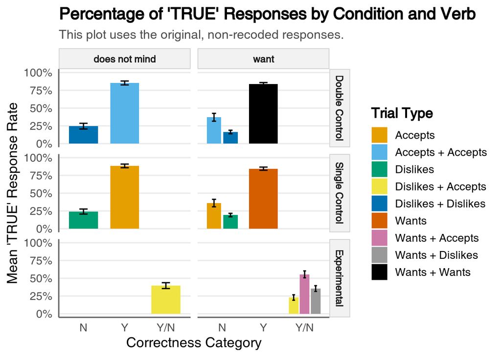

```r
# ----- 1) Summarize Raw Data -----
subject_means_raw <- data_main %>%
  group_by(PARTICIPANT, condition_label, verb, trial_type, correct) %>%
  summarise(mean_resp = mean(resp, na.rm = TRUE), .groups = "drop")

summary_means_raw <- subject_means_raw %>%
  group_by(condition_label, verb, trial_type, correct) %>%
  summarise(
    mean = mean(mean_resp),
    se = sd(mean_resp) / sqrt(n()),
    .groups = "drop"
  )

# ----- 2) Create the Plot -----
ggplot(summary_means_raw, aes(x = correct, y = mean, fill = trial_type)) +
  geom_col(position = position_dodge(width = 0.8), width = 0.7) +
  geom_errorbar(
    aes(ymin = mean - se, ymax = mean + se),
    position = position_dodge(width = 0.8),
    width = 0.2,
    linewidth = 0.6
  ) +
  facet_grid(vars(condition_label), vars(verb)) +
  scale_fill_manual(values = pal_trial_type, name = "Trial Type") +
  scale_y_continuous(labels = percent_format(accuracy = 1), limits = c(0, 1)) +
  labs(
    title = "Percentage of 'TRUE' Responses by Condition and Verb",
    subtitle = "This plot uses the original, non-recoded responses.",
    x = "Correctness Category",
    y = "Mean 'TRUE' Response Rate"
  )
```

### Proportion of “TRUE” Responses (Raw Data) (better plots)

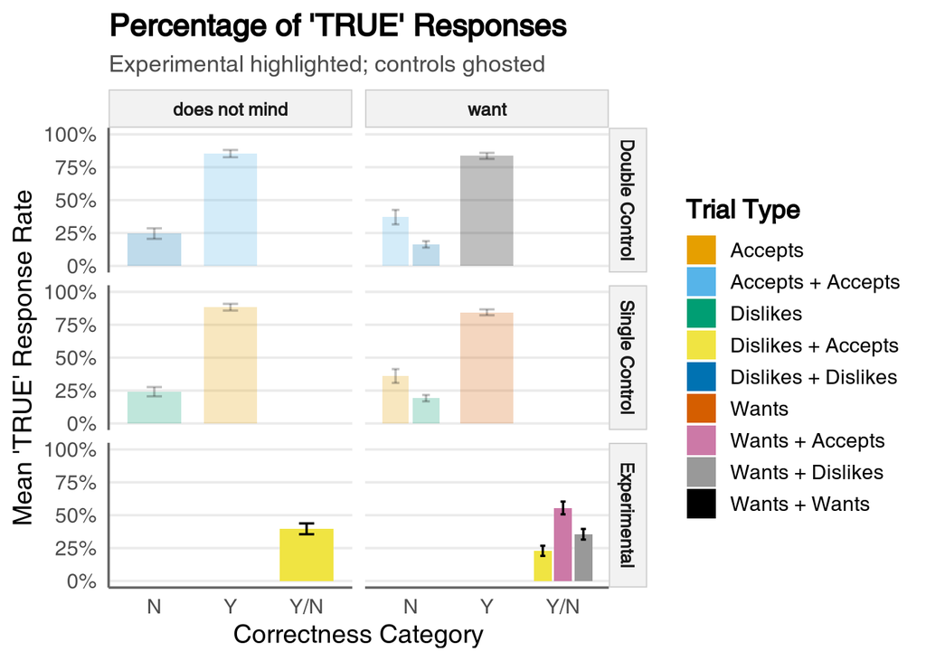

```r
base <- ggplot(
  summary_means_raw,
  aes(x = correct, y = mean, fill = trial_type,
      alpha = condition_label == "Experimental")
) +
  geom_col(position = position_dodge(width = 0.8), width = 0.7) +
  geom_errorbar(aes(ymin = mean - se, ymax = mean + se),
                position = position_dodge(width = 0.8),
                width = 0.2, linewidth = 0.6) +
  facet_grid(vars(condition_label), vars(verb)) +
  scale_fill_manual(values = pal_trial_type, name = "Trial Type") +
  scale_alpha_manual(values = c(`TRUE` = 1, `FALSE` = 0.25), guide = "none") +
  scale_y_continuous(labels = scales::percent_format(accuracy = 1), limits = c(0, 1)) +
  labs(title = "Percentage of 'TRUE' Responses",
       subtitle = "Experimental highlighted; controls ghosted",
       x = "Correctness Category", y = "Mean 'TRUE' Response Rate")

base
```

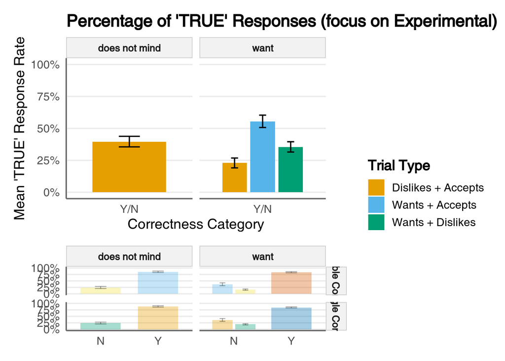

```r
library(patchwork)

p_exp <- ggplot(filter(summary_means_raw, condition_label == "Experimental"),
                aes(correct, mean, fill = trial_type)) +
  geom_col(position = position_dodge(0.8), width = 0.7) +
  geom_errorbar(aes(ymin = mean - se, ymax = mean + se),
                position = position_dodge(0.8), width = 0.2, linewidth = 0.6) +
  facet_grid(. ~ verb) +
  scale_fill_manual(values = pal_trial_type, name = "Trial Type") +
  scale_y_continuous(labels = scales::percent, limits = c(0, 1)) +
  labs(title = "Percentage of 'TRUE' Responses (focus on Experimental)",
       x = "Correctness Category", y = "Mean 'TRUE' Response Rate")

p_ctrl <- ggplot(filter(summary_means_raw, condition_label != "Experimental"),
                 aes(correct, mean, fill = trial_type)) +
  geom_col(position = position_dodge(0.8), width = 0.7, alpha = 0.35) +
  geom_errorbar(aes(ymin = mean - se, ymax = mean + se),
                position = position_dodge(0.8), width = 0.2, linewidth = 0.4, alpha = 0.35) +
  facet_grid(vars(condition_label), vars(verb)) +
  scale_fill_manual(values = pal_trial_type, guide = "none") +
  scale_y_continuous(labels = scales::percent, limits = c(0, 1)) +
  labs(x = NULL, y = NULL)

(p_exp / p_ctrl) + plot_layout(heights = c(2.2, 1), guides = "collect") &
  theme(legend.position = "right")
```

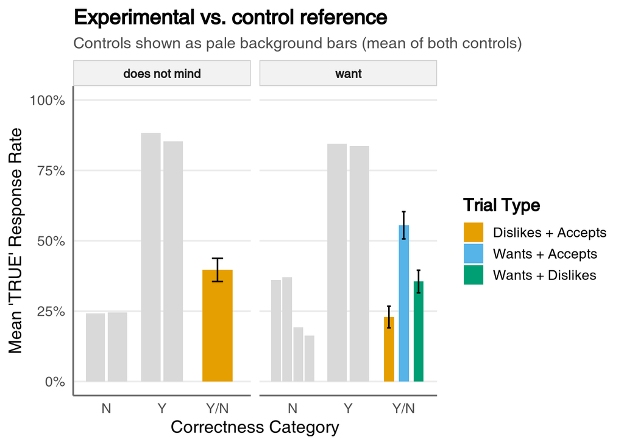

```r
ctrl_bg <- summary_means_raw |>
  dplyr::filter(condition_label != "Experimental") |>
  dplyr::group_by(verb, trial_type, correct) |>
  dplyr::summarise(ctrl_mean = mean(mean), .groups = "drop")

exp_df <- dplyr::filter(summary_means_raw, condition_label == "Experimental")

ggplot() +
  # controls as ghost background
  geom_col(data = ctrl_bg,
           aes(correct, ctrl_mean, group = trial_type),
           position = position_dodge(0.8), width = 0.7,
           fill = "grey85", colour = NA) +
  # experimental on top
  geom_col(data = exp_df,
           aes(correct, mean, fill = trial_type),
           position = position_dodge(0.8), width = 0.55) +
  geom_errorbar(data = exp_df,
                aes(correct, ymin = mean - se, ymax = mean + se, group = trial_type),
                position = position_dodge(0.8), width = 0.2, linewidth = 0.6) +
  facet_grid(. ~ verb) +
  scale_fill_manual(values = pal_trial_type, name = "Trial Type") +
  scale_y_continuous(labels = scales::percent, limits = c(0, 1)) +
  labs(title = "Experimental vs. control reference",
       subtitle = "Controls shown as pale background bars (mean of both controls)",
       x = "Correctness Category", y = "Mean 'TRUE' Response Rate")
```

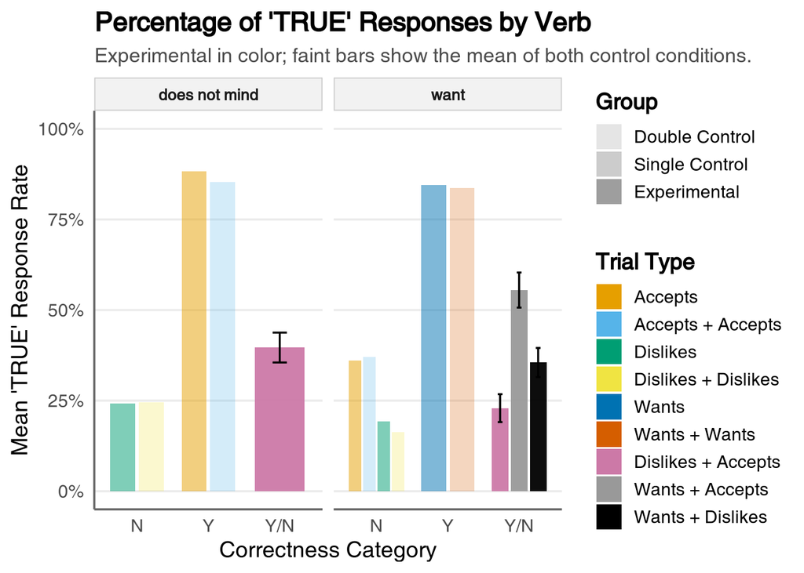

```r
## 1) Prep: control background (average of both controls) + experimental
ctrl_bg <- summary_means_raw %>%
  filter(condition_label != "Experimental") %>%
  group_by(verb, trial_type, correct, source = condition_label) %>%
  summarise(mean = mean(mean), .groups = "drop")


exp_df <- summary_means_raw %>%
  filter(condition_label == "Experimental") %>%
  mutate(source = "Experimental")

## 2) Plot: same widths; alpha-driven legend for source
ggplot() +
  # faint control reference behind
  geom_col(
    data = ctrl_bg,
    aes(correct, mean, fill = trial_type, alpha = source),
    position = position_dodge(0.8),
    width = 0.70,
    colour = NA
  ) +
  # experimental on top (same width), partially transparent if you like
  geom_col(
    data = exp_df,
    aes(correct, mean, fill = trial_type, alpha = source),
    position = position_dodge(0.8),
    width = 0.70
  ) +
  geom_errorbar(
    data = exp_df,
    aes(correct, ymin = mean - se, ymax = mean + se, group = trial_type),
    position = position_dodge(0.8),
    width = 0.20,
    linewidth = 0.6,
    show.legend = FALSE
  ) +
  facet_grid(. ~ verb) +
  scale_fill_manual(values = pal_trial_type, name = "Trial Type") +
  scale_alpha_manual(
    values = c("Experimental" = 0.95, "Single Control" = 0.5, "Double Control" = 0.25),
    name = "Group",
    guide = guide_legend(order = 1, override.aes = list(fill = "grey60", colour = NA))
  ) +
  #scale_alpha_manual(
  #  values = c(
  #    "Experimental" = 0.95,                           # you can set to 1 if you prefer
  #    "Control reference (mean of Single & Double)" = 0.25
  #  ),
  #  name = "Group",
  #  guide = guide_legend(order = 1,
  #                       override.aes = list(fill = "grey60", colour = NA))
  #) +
  guides(fill = guide_legend(order = 2)) +
  scale_y_continuous(labels = scales::percent, limits = c(0, 1)) +
  labs(
    title = "Percentage of 'TRUE' Responses by Verb",
    subtitle = "Experimental in color; faint bars show the mean of both control conditions.",
    x = "Correctness Category", y = "Mean 'TRUE' Response Rate"
  )
```

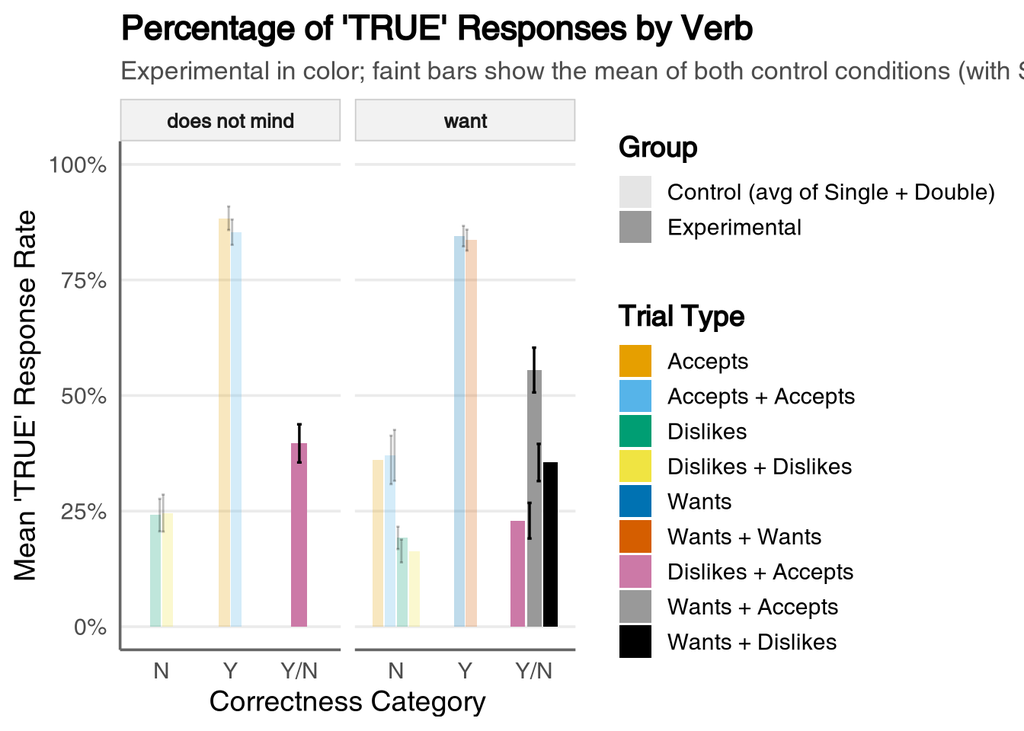

```r
library(dplyr)
library(ggplot2)

# --- Constant dodging object (same for all layers) ---
pd <- position_dodge2(width = 0.80, preserve = "single")

# --- Control reference (avg of Single & Double) with SE ---
ctrl_bg <- subject_means_raw %>%                             # per-participant cell means
  filter(condition_label != "Experimental") %>%
  group_by(PARTICIPANT, verb, trial_type, correct) %>%       # avg the two controls within participant
  summarise(mean_resp = mean(mean_resp), .groups = "drop") %>%
  group_by(verb, trial_type, correct) %>%                    # then mean & SE across participants
  summarise(mean = mean(mean_resp),
            se   = sd(mean_resp) / sqrt(n()), .groups = "drop") %>%
  mutate(source = "Control (avg of Single + Double)")

# --- Experimental with SE (already computed) ---
exp_df <- summary_means_raw %>%
  filter(condition_label == "Experimental") %>%
  transmute(verb, trial_type, correct, mean, se,
            source = "Experimental")

# (Optional) lock factor order so dodging is consistent everywhere
exp_df$trial_type  <- factor(exp_df$trial_type,  levels = levels(ctrl_bg$trial_type))
ctrl_bg$trial_type <- factor(ctrl_bg$trial_type, levels = levels(exp_df$trial_type))

ggplot() +
  # control reference (faint) — bars + error bars
  geom_col(data = ctrl_bg,
           aes(correct, mean, fill = trial_type, alpha = source),
           position = pd, width = 0.70, colour = NA) +
  geom_errorbar(data = ctrl_bg,
                aes(correct, ymin = mean - se, ymax = mean + se,
                    alpha = source, group = trial_type),
                position = pd, width = 0.20, linewidth = 0.5,
                show.legend = FALSE) +
  # experimental (on top) — bars + error bars
  geom_col(data = exp_df,
           aes(correct, mean, fill = trial_type, alpha = source),
           position = pd, width = 0.70) +
  geom_errorbar(data = exp_df,
                aes(correct, ymin = mean - se, ymax = mean + se,
                    alpha = source, group = trial_type),
                position = pd, width = 0.20, linewidth = 0.6,
                show.legend = FALSE) +
  facet_grid(. ~ verb) +
  scale_fill_manual(values = pal_trial_type, name = "Trial Type") +
  scale_alpha_manual(
    values = c("Experimental" = 1, "Control (avg of Single + Double)" = 0.25),
    name   = "Group",
    guide  = guide_legend(order = 1,
                          override.aes = list(fill = "grey60", colour = NA))
  ) +
  guides(fill = guide_legend(order = 2)) +
  scale_y_continuous(labels = scales::percent, limits = c(0, 1)) +
  labs(
    title = "Percentage of 'TRUE' Responses by Verb",
    subtitle = "Experimental in color; faint bars show the mean of both control conditions (with SE).",
    x = "Correctness Category", y = "Mean 'TRUE' Response Rate"
  )
```

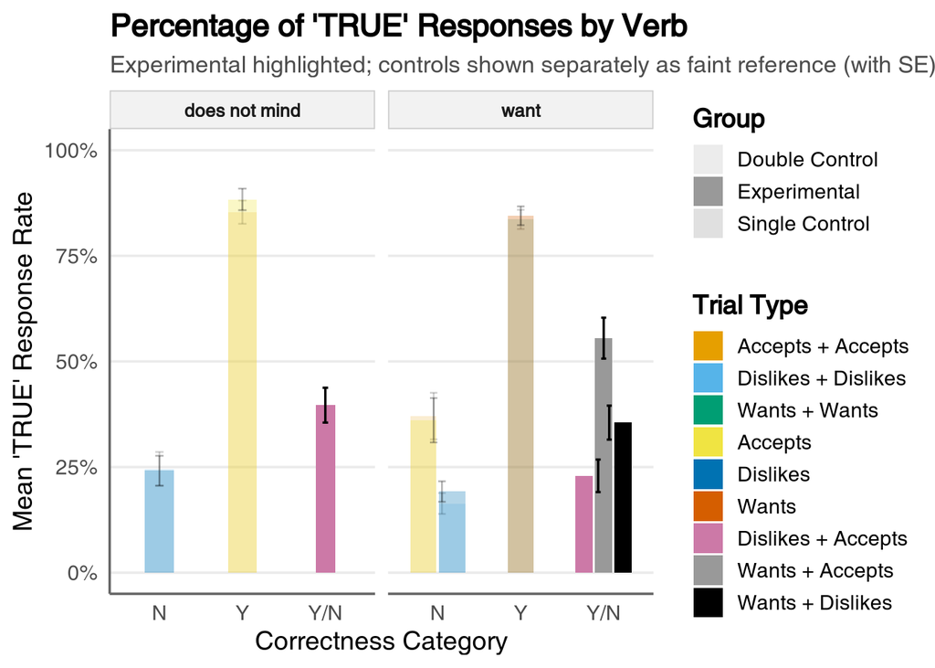

```r
library(dplyr)
library(ggplot2)

# --- ensure consistent x-order (optional)
summary_means_raw <- summary_means_raw %>%
  mutate(correct = factor(correct, levels = c("N","Y","Y/N")))

# Split data
exp_df <- summary_means_raw %>%
  filter(condition_label == "Experimental") %>%
  mutate(source = "Experimental")

ctrl_single <- summary_means_raw %>%
  filter(condition_label == "Single Control") %>%
  mutate(source = "Single Control")

ctrl_double <- summary_means_raw %>%
  filter(condition_label == "Double Control") %>%
  mutate(source = "Double Control")

# Use the same levels and one dodger everywhere (guarantees identical widths)
lvl_tt <- levels(summary_means_raw$trial_type) %||% unique(summary_means_raw$trial_type)
exp_df$trial_type      <- factor(exp_df$trial_type,      levels = lvl_tt)
ctrl_single$trial_type <- factor(ctrl_single$trial_type, levels = lvl_tt)
ctrl_double$trial_type <- factor(ctrl_double$trial_type, levels = lvl_tt)

pd <- position_dodge2(width = 0.80, preserve = "single")  # <- key for equal widths
bar_w <- 0.70

ggplot() +
  # controls in the background (draw the taller first so shorter is visible)
  geom_col(data = ctrl_double,
           aes(correct, mean, fill = trial_type, alpha = source),
           position = pd, width = bar_w, colour = NA) +
  geom_errorbar(data = ctrl_double,
                aes(correct, ymin = mean - se, ymax = mean + se,
                    alpha = source, group = trial_type),
                position = pd, width = 0.20, linewidth = 0.45,
                show.legend = FALSE) +

  geom_col(data = ctrl_single,
           aes(correct, mean, fill = trial_type, alpha = source),
           position = pd, width = bar_w, colour = NA) +
  geom_errorbar(data = ctrl_single,
                aes(correct, ymin = mean - se, ymax = mean + se,
                    alpha = source, group = trial_type),
                position = pd, width = 0.20, linewidth = 0.45,
                show.legend = FALSE) +

  # experimental on top
  geom_col(data = exp_df,
           aes(correct, mean, fill = trial_type, alpha = source),
           position = pd, width = bar_w) +
  geom_errorbar(data = exp_df,
                aes(correct, ymin = mean - se, ymax = mean + se,
                    alpha = source, group = trial_type),
                position = pd, width = 0.20, linewidth = 0.60,
                show.legend = FALSE) +

  facet_grid(. ~ verb) +
  scale_fill_manual(values = pal_trial_type, name = "Trial Type") +
  scale_alpha_manual(
    values = c("Experimental" = 1.0,
               "Single Control" = 0.30,
               "Double Control" = 0.18),
    name = "Group",
    guide = guide_legend(order = 1,
                         override.aes = list(fill = "grey60", colour = NA))
  ) +
  guides(fill = guide_legend(order = 2)) +
  scale_y_continuous(labels = scales::percent, limits = c(0, 1)) +
  labs(
    title = "Percentage of 'TRUE' Responses by Verb",
    subtitle = "Experimental highlighted; controls shown separately as faint reference (with SE).",
    x = "Correctness Category", y = "Mean 'TRUE' Response Rate"
  )
```

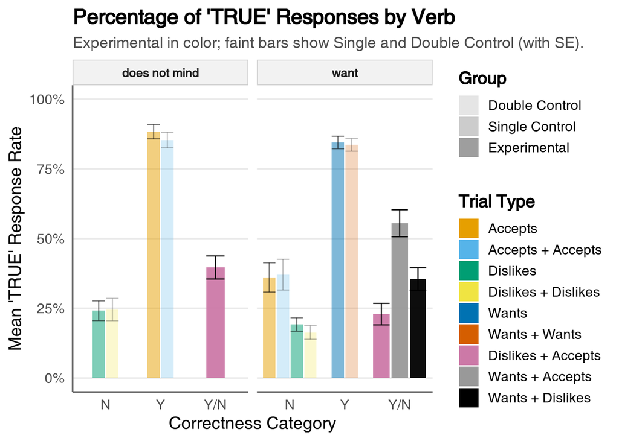

```r
## 1) Prep: keep per-control stats (mean + se) and tag source
pd <- position_dodge2(width = 0.10, preserve = "single")  # <- key for equal widths

ctrl_bg <- summary_means_raw %>%
  dplyr::filter(condition_label != "Experimental") %>%
  dplyr::transmute(
    verb, trial_type, correct,
    mean, se,
    source = condition_label   # "Single Control" / "Double Control"
  )

exp_df <- summary_means_raw %>%
  dplyr::filter(condition_label == "Experimental") %>%
  dplyr::mutate(source = "Experimental")

## 2) Plot: add error bars for controls
ggplot() +
  # faint controls (bars + error bars)
  geom_col(
    data = ctrl_bg,
    aes(correct, mean, fill = trial_type, alpha = source),
    position = pd,
    width = 1,
    colour = NA
  ) +
  geom_errorbar(
    data = ctrl_bg,
    aes(correct, ymin = mean - se, ymax = mean + se,
        alpha = source, group = trial_type),
    position = pd,
    width = 1,
    linewidth = 0.45,
    show.legend = FALSE
  ) +
  geom_col(
    data = exp_df,
    aes(correct, mean, fill = trial_type, alpha = source),
    position = pd,
    width = 1
  ) +
  geom_errorbar(
    data = exp_df,
    aes(correct, ymin = mean - se, ymax = mean + se, group = trial_type),
    position = pd,
    width = 1.,
    linewidth = 0.45,
    show.legend = FALSE
  ) +
  facet_grid(. ~ verb) +
  scale_fill_manual(values = pal_trial_type, name = "Trial Type") +
  scale_alpha_manual(
    values = c("Experimental" = 0.95, "Single Control" = 0.5, "Double Control" = 0.25),
    name = "Group",
    guide = guide_legend(order = 1, override.aes = list(fill = "grey60", colour = NA))
  ) +
  guides(fill = guide_legend(order = 2)) +
  scale_y_continuous(labels = scales::percent, limits = c(0, 1)) +
  labs(
    title = "Percentage of 'TRUE' Responses by Verb",
    subtitle = "Experimental in color; faint bars show Single and Double Control (with SE).",
    x = "Correctness Category", y = "Mean 'TRUE' Response Rate"
  )
```

### Response Accuracy by Condition

Next, we visualize the proportion of **correct** responses (`resp_adj`) for the verb “want” across different conditions and trial types.

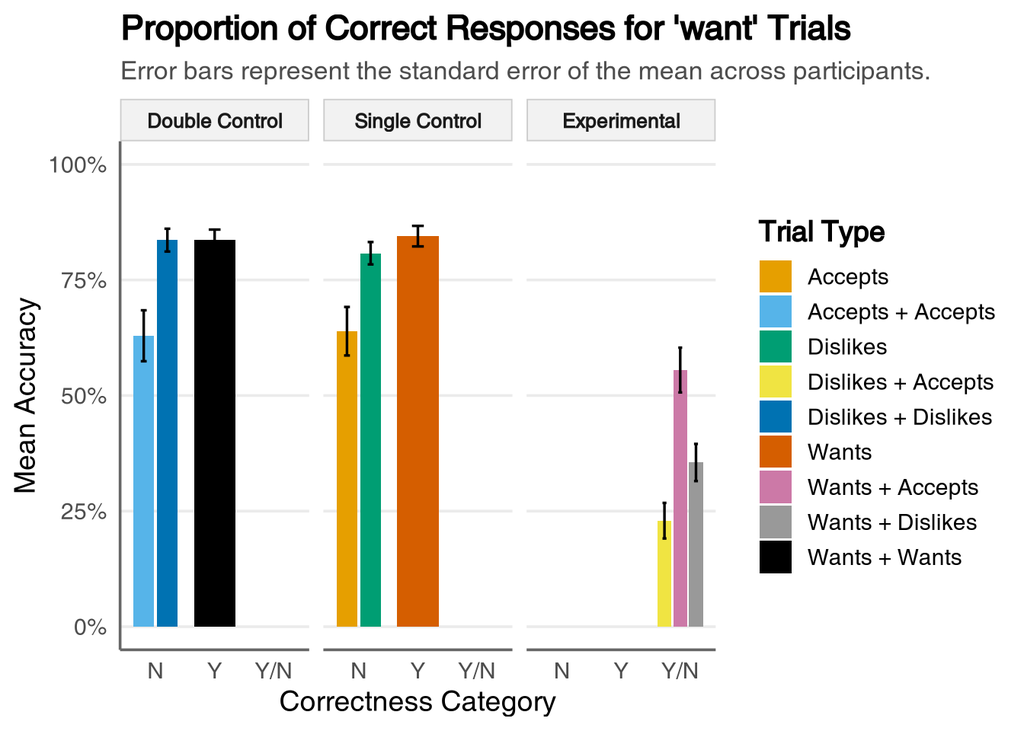

```r
# ----- 1) Summarize Data -----
subject_means <- data_main %>%
  filter(verb == "want") %>%
  group_by(PARTICIPANT, condition_label, correct, trial_type) %>%
  summarise(mean_resp_adj = mean(resp_adj, na.rm = TRUE), .groups = "drop")

summary_means <- subject_means %>%
  group_by(condition_label, correct, trial_type) %>%
  summarise(
    mean = mean(mean_resp_adj),
    se = sd(mean_resp_adj) / sqrt(n()),
    .groups = "drop"
  )

# ----- 2) Create the Plot -----
ggplot(summary_means, aes(x = correct, y = mean, fill = trial_type)) +
  geom_col(position = position_dodge(width = 0.8), width = 0.7) +
  geom_errorbar(
    aes(ymin = mean - se, ymax = mean + se),
    position = position_dodge(width = 0.8),
    width = 0.2,
    linewidth = 0.6
  ) +
  facet_wrap(~condition_label) +
  scale_fill_manual(values = pal_trial_type, name = "Trial Type") +
  scale_y_continuous(labels = percent_format(accuracy = 1), limits = c(0, 1)) +
  labs(
    title = "Proportion of Correct Responses for 'want' Trials",
    subtitle = "Error bars represent the standard error of the mean across participants.",
    x = "Correctness Category",
    y = "Mean Accuracy"
  )
```

### Full Model (Logistic Mixed-Effects)

A generalized linear mixed-effects model (`glmer`) is used to test the effects of `trial_type` and `condition` (single vs. double control) on response accuracy.

```r
fit_glmer <- glmer(
  resp_adj ~ trial_type * single_or_double + (1 | PARTICIPANT),
  data = data_main %>% filter(verb == "want"),
  family = binomial,
  control = glmerControl(optimizer = "bobyqa", optCtrl = list(maxfun = 2e5))
)
tab_model(fit_glmer)
```

|  | resp_adj |  |  |
| --- | --- | --- | --- |
| Predictors | Odds Ratios | CI | p |
| (Intercept) | 1.87 | 1.51 – 2.33 | **<0.001** |
| trial type [Accepts + Accepts] | 0.96 | 0.76 – 1.20 | 0.696 |
| trial type [Dislikes] | 2.51 | 1.99 – 3.17 | **<0.001** |
| trial type [Dislikes + Accepts] | 0.14 | 0.11 – 0.19 | **<0.001** |
| trial type [Dislikes + Dislikes] | 3.08 | 2.35 – 4.03 | **<0.001** |
| trial type [Wants] | 3.29 | 2.58 – 4.20 | **<0.001** |
| trial type [Wants + Accepts] | 0.68 | 0.55 – 0.86 | **0.001** |
| trial type [Wants + Dislikes] | 0.28 | 0.22 – 0.35 | **<0.001** |
| trial type [Wants + Wants] | 3.08 | 2.35 – 4.03 | **<0.001** |
| Random Effects |  |  |  |
| σ<sup>2</sup> | 3.29 |  |  |
| τ<sub>00</sub> <sub>PARTICIPANT</sub> | 0.39 |  |  |
| ICC | 0.11 |  |  |
| N <sub>PARTICIPANT</sub> | 58 |  |  |
| Observations | 5916 |  |  |
| Marginal R<sup>2</sup> / Conditional R<sup>2</sup> | 0.226 / 0.308 |  |  |

## Distribution of Responses in Experimental Condition

We now focus on the **EXPERIMENTAL** condition to see how individual participants behaved. A histogram of participant-level accuracy can reveal if there are distinct sub-groups.

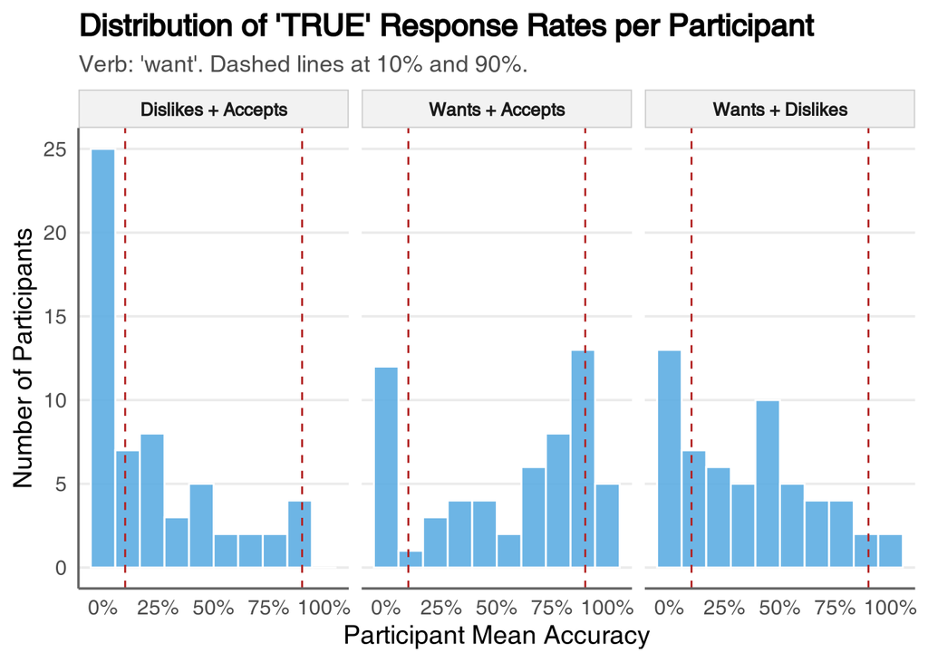

```r
# ----- 1) Calculate Participant-level Accuracy -----
prop_by_part <- data_main %>%
  filter(
    condition == "EXPERIMENTAL",
    verb == "want"
  ) %>%
  group_by(PARTICIPANT, trial_type) %>%
  summarise(p = mean(resp_adj, na.rm = TRUE), .groups = "drop")

# ----- 2) Create the Plot -----
ggplot(prop_by_part, aes(x = p)) +
  geom_histogram(bins = 10, fill = "#5DADE2", color = "white", alpha = 0.9) +
  geom_vline(xintercept = c(.10, .90), linetype = "dashed", color = "firebrick") +
  scale_x_continuous(labels = percent_format()) +
  facet_wrap(~trial_type) +
  labs(
    # *** UPDATED: More precise title ***
    title = "Distribution of 'TRUE' Response Rates per Participant",
    subtitle = "Verb: 'want'. Dashed lines at 10% and 90%.",
    x = "Participant Mean Accuracy",
    y = "Number of Participants"
  )
```

### Test for Bimodality

We use Hartigan’s Dip Test to statistically assess whether the distributions observed above are significantly different from unimodal. A small p-value (e.g., < 0.05) suggests the distribution is not unimodal.

```r
# Function to run and print dip test for a given trial type
run_dip_test <- function(df, type) {
  cat(paste("--- Dip Test for:", type, "---\n"))
  data_subset <- df %>% filter(trial_type == type) %>% pull(p)
  print(dip.test(data_subset))
}

run_dip_test(prop_by_part, "Dislikes + Accepts")
```

```
## --- Dip Test for: Dislikes + Accepts ---
##
##  Hartigans' dip test for unimodality / multimodality
##
## data:  data_subset
## D = 0.068966, p-value = 0.03292
## alternative hypothesis: non-unimodal, i.e., at least bimodal
```

```r
run_dip_test(prop_by_part, "Wants + Accepts")
```

```
## --- Dip Test for: Wants + Accepts ---
##
##  Hartigans' dip test for unimodality / multimodality
##
## data:  data_subset
## D = 0.10345, p-value = 2.439e-05
## alternative hypothesis: non-unimodal, i.e., at least bimodal
```

```r
run_dip_test(prop_by_part, "Wants + Dislikes")
```

```
## --- Dip Test for: Wants + Dislikes ---
##
##  Hartigans' dip test for unimodality / multimodality
##
## data:  data_subset
## D = 0.060345, p-value = 0.1033
## alternative hypothesis: non-unimodal, i.e., at least bimodal
```

# Part 2: Response Time (RT) Analysis

Before analyzing RTs, we filter out outliers to ensure the data is clean. We remove trials faster than 200ms and those beyond 2.5 median absolute deviations (MAD) from the median log-RT.

```r
# ----- 1) Outlier Filtering Function -----
filter_rt_outliers <- function(data, rt_col = "rt", lower_ms = 200, mad_cutoff = 2.5) {
  data %>%
    filter(.data[[rt_col]] >= lower_ms) %>%
    mutate(log_rt = log(.data[[rt_col]])) %>%
    group_by(PARTICIPANT) %>%
    mutate(
      med_log = median(log_rt, na.rm = TRUE),
      mad_log = mad(log_rt, constant = 1, na.rm = TRUE)
    ) %>%
    ungroup() %>%
    filter(abs(log_rt - med_log) <= mad_cutoff * mad_log) %>%
    select(-log_rt, -med_log, -mad_log) # Clean up helper columns
}

# ----- 2) Apply Filter and Prepare RT Data -----
data_rt_clean <- data_main %>%
  filter(!is.na(rt)) %>%
  filter_rt_outliers() %>%
  mutate(
    # Create a factor for the adjusted response (Correct/Incorrect)
    resp_nom_adj = if_else(resp_adj == 1, "Correct", "Incorrect"),
    rt_log = log(rt)
  )
```

## Log-Transformed RT Analysis

Log-transforming RTs often helps normalize their distribution. We will focus on the log-transformed data.

### Full Model (Linear Mixed-Effects)

We model log-RT as a function of response accuracy (`resp_nom_adj`) and `trial_type`, with random intercepts for participant and item.

```r
fit_lmer_log <- lmer(
  rt_log ~ resp_nom_adj * trial_type + (1 | PARTICIPANT) + (1 | item),
  data = data_rt_clean %>% filter(verb == "want")
)
tab_model(fit_lmer_log)
```

|  | rt_log |  |  |
| --- | --- | --- | --- |
| Predictors | Estimates | CI | p |
| (Intercept) | 7.30 | 7.18 – 7.42 | **<0.001** |
| resp nom adj [Incorrect] | -0.08 | -0.15 – -0.02 | **0.006** |
| trial type [Accepts + Accepts] | 0.11 | 0.06 – 0.17 | **<0.001** |
| trial type [Dislikes] | 0.05 | 0.00 – 0.10 | **0.046** |
| trial type [Dislikes + Accepts] | 0.11 | 0.03 – 0.20 | **0.011** |
| trial type [Dislikes + Dislikes] | 0.21 | 0.15 – 0.26 | **<0.001** |
| trial type [Wants] | 0.06 | 0.01 – 0.11 | **0.027** |
| trial type [Wants + Accepts] | 0.29 | 0.23 – 0.35 | **<0.001** |
| trial type [Wants + Dislikes] | 0.33 | 0.26 – 0.40 | **<0.001** |
| trial type [Wants + Wants] | 0.19 | 0.14 – 0.25 | **<0.001** |
| resp nom adj [Incorrect] × trial type [Accepts + Accepts] | -0.03 | -0.12 – 0.06 | 0.509 |
| resp nom adj [Incorrect] × trial type [Dislikes] | 0.25 | 0.16 – 0.35 | **<0.001** |
| resp nom adj [Incorrect] × trial type [Dislikes + Accepts] | 0.32 | 0.21 – 0.43 | **<0.001** |
| resp nom adj [Incorrect] × trial type [Dislikes + Dislikes] | 0.08 | -0.03 – 0.19 | 0.137 |
| resp nom adj [Incorrect] × trial type [Wants] | 0.23 | 0.13 – 0.33 | **<0.001** |
| resp nom adj [Incorrect] × trial type [Wants + Accepts] | 0.07 | -0.03 – 0.16 | 0.166 |
| resp nom adj [Incorrect] × trial type [Wants + Dislikes] | 0.06 | -0.03 – 0.16 | 0.213 |
| resp nom adj [Incorrect] × trial type [Wants + Wants] | 0.08 | -0.03 – 0.19 | 0.162 |
| Random Effects |  |  |  |
| σ<sup>2</sup> | 0.14 |  |  |
| τ<sub>00</sub> <sub>item</sub> | 0.00 |  |  |
| τ<sub>00</sub> <sub>PARTICIPANT</sub> | 0.19 |  |  |
| ICC | 0.58 |  |  |
| N <sub>PARTICIPANT</sub> | 58 |  |  |
| N <sub>item</sub> | 102 |  |  |
| Observations | 5230 |  |  |
| Marginal R<sup>2</sup> / Conditional R<sup>2</sup> | 0.045 / 0.594 |  |  |

### Post-hoc Comparisons

We use `emmeans` to perform pairwise comparisons of the estimated marginal means from our model. This helps clarify the interaction between response accuracy and trial type.

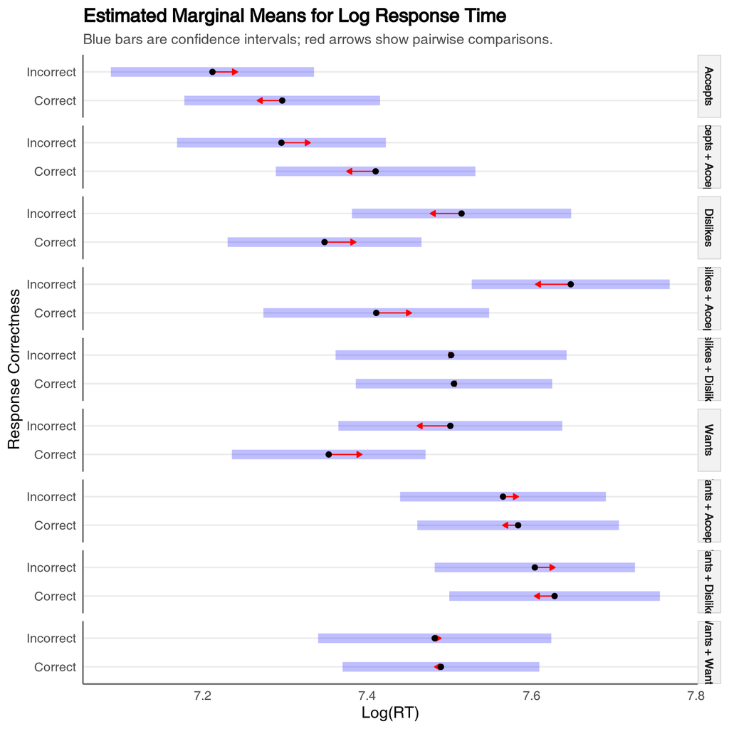

```r
emm_log <- emmeans(fit_lmer_log, ~ resp_nom_adj | trial_type, lmer.df = "asymptotic")

emm_log_for_plot <- emm_log

# Rename the label for the 'trial_type' variable to an empty string
# The plot function uses the names of this list to create panel labels
names(emm_log_for_plot@levels)[names(emm_log_for_plot@levels) == "trial_type"] <- ""

# Plot the modified object
p <- plot(emm_log_for_plot, comparisons = TRUE) +
  theme_report() +
  labs(
    title = "Estimated Marginal Means for Log Response Time",
    subtitle = "Blue bars are confidence intervals; red arrows show pairwise comparisons.",
    x = "Log(RT)",
    y = "Response Correctness"
  )

p$facet$params$labeller <- labeller(trial_type = label_value)
p
```

```r
# Show the pairwise comparisons in a table
broom::tidy(pairs(emm_log, adjust = "tukey")) %>%
  flextable() %>%
  colformat_double(digits = 3) %>%
  set_caption("Pairwise Comparisons of EMMs for Log-RT") %>%
  autofit()
```

Pairwise Comparisons of EMMs for Log-RT

| trial_type | term | contrast | null.value | estimate | std.error | df | statistic | p.value |
| --- | --- | --- | --- | --- | --- | --- | --- | --- |
| Accepts | resp_nom_adj | Correct - Incorrect | 0.000 | 0.085 | 0.031 | Inf | 2.733 | 0.006 |
| Accepts + Accepts | resp_nom_adj | Correct - Incorrect | 0.000 | 0.114 | 0.036 | Inf | 3.197 | 0.001 |
| Dislikes | resp_nom_adj | Correct - Incorrect | 0.000 | -0.167 | 0.039 | Inf | -4.294 | 0.000 |
| Dislikes + Accepts | resp_nom_adj | Correct - Incorrect | 0.000 | -0.236 | 0.044 | Inf | -5.407 | 0.000 |
| Dislikes + Dislikes | resp_nom_adj | Correct - Incorrect | 0.000 | 0.004 | 0.046 | Inf | 0.077 | 0.939 |
| Wants | resp_nom_adj | Correct - Incorrect | 0.000 | -0.148 | 0.041 | Inf | -3.587 | 0.000 |
| Wants + Accepts | resp_nom_adj | Correct - Incorrect | 0.000 | 0.018 | 0.035 | Inf | 0.525 | 0.600 |
| Wants + Dislikes | resp_nom_adj | Correct - Incorrect | 0.000 | 0.024 | 0.037 | Inf | 0.651 | 0.515 |
| Wants + Wants | resp_nom_adj | Correct - Incorrect | 0.000 | 0.008 | 0.047 | Inf | 0.162 | 0.871 |

### Log-RT Visualization

A line plot helps visualize the interaction between response correctness and trial type on response times.

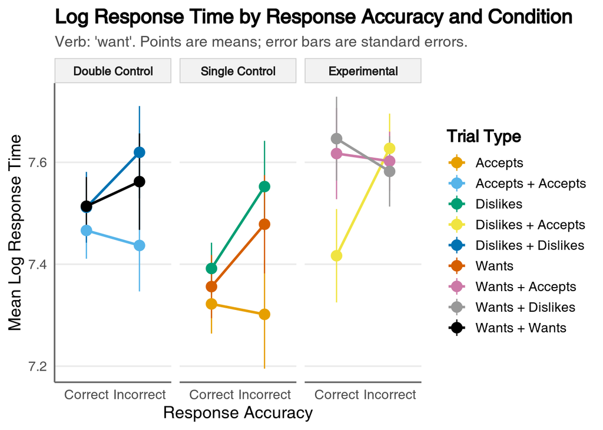

```r
# ----- 1) Summarize Data -----
rt_summary <- data_rt_clean %>%
  filter(verb == "want") %>%
  group_by(PARTICIPANT, condition_label, trial_type, resp_nom_adj) %>%
  summarise(mean_rt_log = mean(rt_log, na.rm = TRUE), .groups = "drop")

# ----- 2) Create the Plot -----
ggplot(rt_summary, aes(x = resp_nom_adj, y = mean_rt_log, color = trial_type, group = trial_type)) +
  stat_summary(fun.data = "mean_se", geom = "line", linewidth = 1) +
  stat_summary(fun.data = "mean_se", geom = "pointrange", size = 0.8, pch = 19) +
  facet_wrap(~condition_label) +
  scale_color_manual(values = pal_trial_type, name = "Trial Type") +
  labs(
    title = "Log Response Time by Response Accuracy and Condition",
    subtitle = "Verb: 'want'. Points are means; error bars are standard errors.",
    x = "Response Accuracy",
    y = "Mean Log Response Time"
  )
```